# Default of Credit Card Clients Dataset

```r
pay_1_default_perc.df
```

```
##    level default.count percentage
## 1     -2           365      13.23
## 2     -1           954      16.78
## 3      0          1888      12.81
## 4      1          1252      33.95
## 5      2          1844      69.14
## 6      3           244      75.78
## 7      4            52      68.42
## 8      5            13      50.00
## 9      6             6      54.55
## 10     7             7      77.78
## 11     8            11      57.89
```

5.4.4 Plotting the graph defaulter %age graph as per PAY_1 values

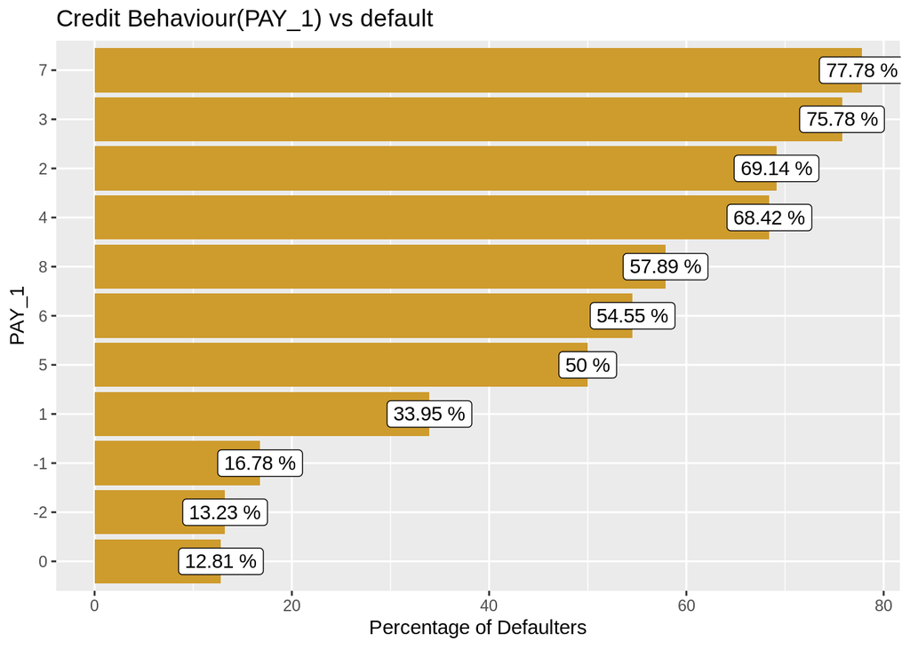

```r
#PAY_1
ggplot(data = pay_1_default_perc.df, mapping = aes(x = reorder(level, percentage), y = percentage)) +
  geom_bar(stat = "identity", fill = "#ce9b2d") +
  coord_flip() +
  xlab("PAY_1") +
  ylab("Percentage of Defaulters") +
  ggtitle("Credit Behaviour(PAY_1) vs default") +
  geom_label(label = paste(pay_1_default_perc.df$percentage, "%"))
```

**5.5 Add one feature REMAINING_AMT_PER**  
REMAINING_AMT_PER is the percentage of difference of total Bill_Amt of 6 months  
and total Pay_Amt of 6 months.

```r
check = calDiffBillAndPayPer(x = our.data, bill_amt_ind = c(13:18), pay_amt_ind = c(19:24))
our.data$REMAINING_AMT_PER = check
```

**5.6 Add one more feature REMAINING_AMT_PER_RANGE**  
Dividing the remaining amount percentage into percentage range  
0-10 -> 0  
11-20 -> 1  
21-30 -> 2  
31-40 -> 3  
41-50 -> 4  
51-60 -> 5  
61-70 -> 6  
71-80 -> 7  
81-90 -> 8  
91-100 -> 9

```r
check = getRemPerRange(x = our.data,
                       colInd = which(colnames(our.data) == 'REMAINING_AMT_PER'))
our.data$REMAINING_AMT_PER_RANGE = check
```

5.6.1 Converting it into categorical variable

```r
# change it to factors
our.data$REMAINING_AMT_PER_RANGE = as.factor(our.data$REMAINING_AMT_PER_RANGE)
```

5.6.2 Finding the %age of defaulters as per remaining_amt_perc

```r
# Explore REMAINING_AMT_PER_RANGE vs default
RemainingAmtPerc_per_df = calDefaultPerc(x = our.data,
                                        colInd = which(colnames(our.data) == "REMAINING_AMT_PER_RANGE"),
                                        data.level = levels(our.data$REMAINING_AMT_PER_RANGE))
```

```r
RemainingAmtPerc_per_df
```

```
##    level default.count percentage
## 1     -1           454      14.87
## 2      0           601      22.69
## 3      1           151      15.02
## 4      2           130      14.82
## 5      3           127      15.30
## 6      4           148      16.70
## 7      5           123      14.86
## 8      6           157      14.71
## 9      7           224      15.71
## 10     8           529      20.42
## 11     9          3992      26.99
```

5.6.3 Plotting a Bar graph of defaulters % as per their remaining amount percentage

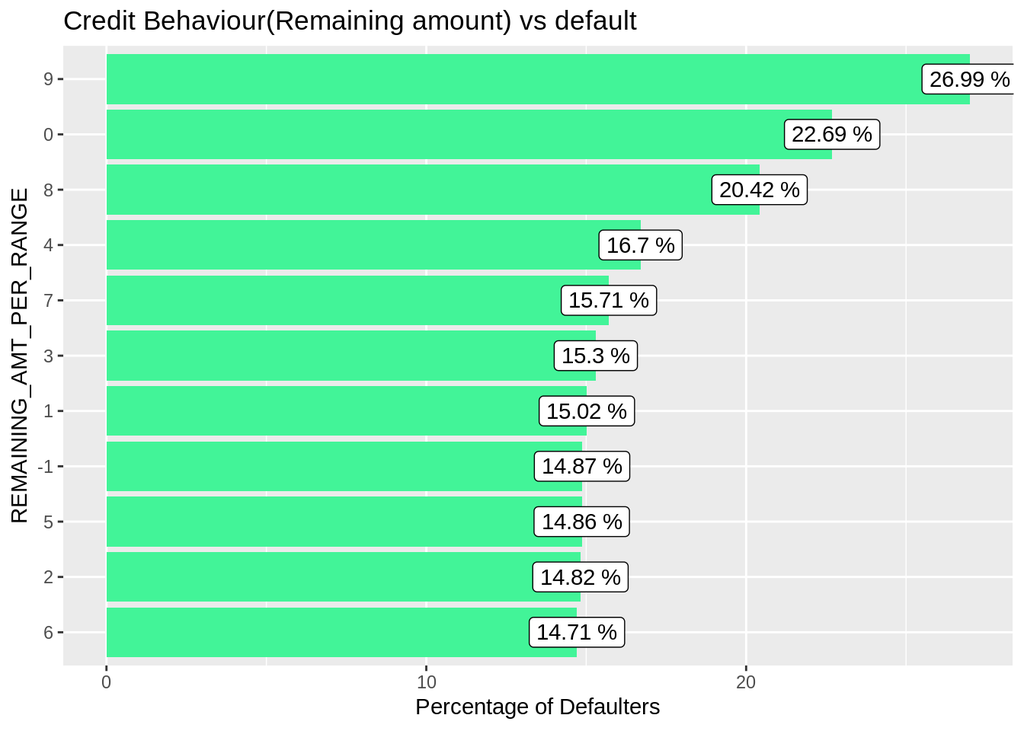

```r
#REMAINING_AMT_PER_RANGE
ggplot(data = RemainingAmtPerc_per_df, mapping = aes(x = reorder(level, percentage), y = percentage)) +
  geom_bar(stat = "identity", fill = "#42f498") +
  coord_flip() +
  xlab("REMAINING_AMT_PER_RANGE") +
  ylab("Percentage of Defaulters") +
  ggtitle("Credit Behaviour(Remaining amount) vs default") +
  geom_label(label = paste(RemainingAmtPerc_per_df$percentage, "%"))
```

**5.7 LIMIT_BAL**

5.7.1 Find the min and max of LIMIT_BAL

```r
summary(our.data$LIMIT_BAL)
```

```
##    Min. 1st Qu.  Median    Mean 3rd Qu.    Max.
##   10000   50000  140000  167484  240000 1000000
```

5.7.2 Plotting a Density curve for LIMIT_BAL

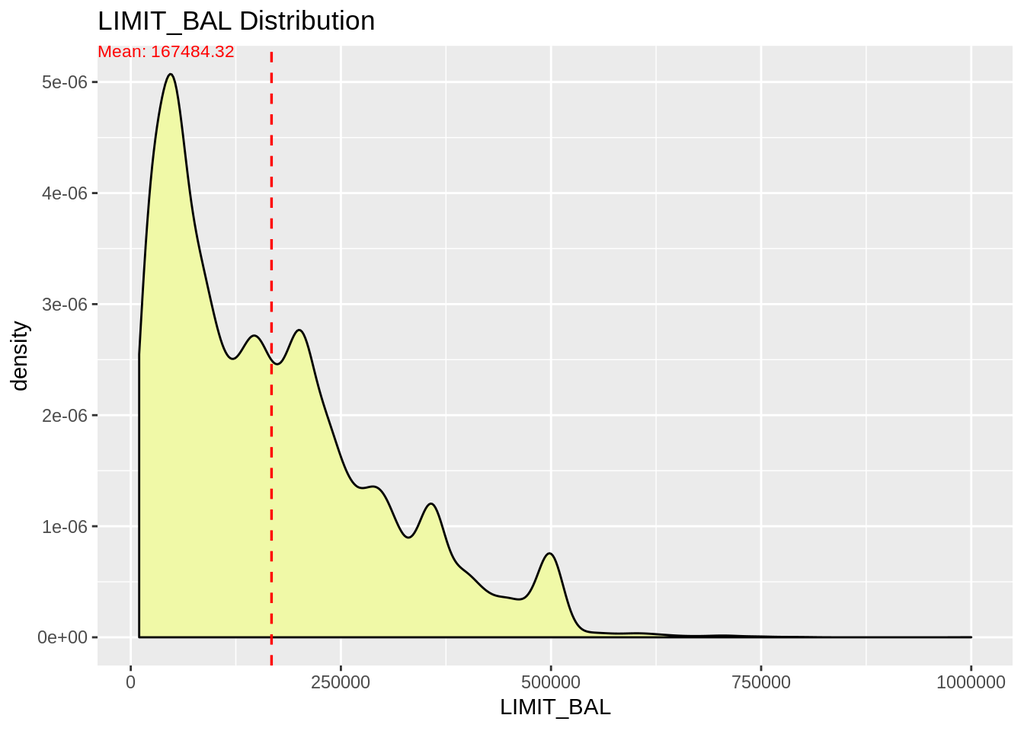

```r
# LIMIT_BAL density plot
ggplot(data = our.data, mapping = aes(x = LIMIT_BAL)) +
  geom_density(fill = "#f0f9a7") +
  ggtitle("LIMIT_BAL Distribution") +
  xlab("LIMIT_BAL") +
  geom_vline(xintercept = mean(our.data$LIMIT_BAL), col = "red",
             linetype = "dashed", size = 0.6) +
  annotate("text",
           x = -Inf, y = Inf,
           label = paste("Mean:", round(mean(our.data$LIMIT_BAL), digits = 2)),
           hjust = 0, vjust = 1, col = "red", size = 3)
```

5.7.3 Divide LIMIT_BAL into segement

```r
limit_bal_seg = getLimitBalRange(x = our.data,
                                 colInd = which(colnames(our.data) == 'LIMIT_BAL'))
```

5.7.4 Add a new feature LIMIT_BAL_SEG

```r
our.data$LIMIT_BAL_SEG = limit_bal_seg
```

5.7.5 Convert it into categorical variable

```r
# change it into factor
our.data$LIMIT_BAL_SEG = as.factor(our.data$LIMIT_BAL_SEG)
```

## 6. Modelling

**6.1 Sampling the data into test and training set** 6.1.1 Taking significant columns

```r
remove_feature = c(1, 26, 27, 29, 30)
our.modified.data = our.data[, -remove_feature]
```

Structure of our final data set

```r
str(our.modified.data)
```

```
## 'data.frame':    30000 obs. of  25 variables:
##  $ LIMIT_BAL        : num  20000 120000 90000 50000 50000 50000 500000 100000 140000 20000 ...
##  $ SEX              : Factor w/ 2 levels "1","2": 2 2 2 2 1 1 1 2 2 1 ...
##  $ EDUCATION        : Factor w/ 4 levels "1","2","3","4": 2 2 2 2 2 1 1 2 3 3 ...
##  $ MARRIAGE         : Factor w/ 3 levels "0","1","2": 2 3 3 2 2 3 3 3 2 3 ...
##  $ AGE              : int  24 26 34 37 57 37 29 23 28 35 ...
##  $ PAY_1            : Factor w/ 11 levels "-2","-1","0",..: 5 2 3 3 2 3 3 3 3 1 ...
##  $ PAY_2            : int  2 2 0 0 0 0 0 -1 0 -2 ...
##  $ PAY_3            : int  -1 0 0 0 -1 0 0 -1 2 -2 ...
##  $ PAY_4            : int  -1 0 0 0 0 0 0 0 0 -2 ...
##  $ PAY_5            : int  -2 0 0 0 0 0 0 0 0 -1 ...
##  $ PAY_6            : int  -2 2 0 0 0 0 0 -1 0 -1 ...
##  $ BILL_AMT1        : num  3913 2682 29239 46990 8617 ...
##  $ BILL_AMT2        : num  3102 1725 14027 48233 5670 ...
##  $ BILL_AMT3        : num  689 2682 13559 49291 35835 ...
##  $ BILL_AMT4        : num  0 3272 14331 28314 20940 ...
##  $ BILL_AMT5        : num  0 3455 14948 28959 19146 ...
##  $ BILL_AMT6        : num  0 3261 15549 29547 19131 ...
##  $ PAY_AMT1         : num  0 0 1518 2000 2000 ...
##  $ PAY_AMT2         : num  689 1000 1500 2019 36681 ...
##  $ PAY_AMT3         : num  0 1000 1000 1200 10000 657 38000 0 432 0 ...
##  $ PAY_AMT4         : num  0 1000 1000 1100 9000 ...
##  $ PAY_AMT5         : num  0 0 1000 1069 689 ...
##  $ PAY_AMT6         : num  0 2000 5000 1000 679 ...
##  $ DEFAULT          : Factor w/ 2 levels "0","1": 2 2 1 1 1 1 1 1 1 1 ...
##  $ REMAINING_AMT_PER: num  91.1 70.7 89.2 96.4 46 ...
```

6.1.2 Sampling

```r
# Sampling the data into test set and training set
index = createDataPartition(y = our.modified.data$DEFAULT, times = 1,
                            p = 0.8, list = F)
trd = our.modified.data[index, ]
tsd = our.modified.data[-index, ]
```

Checking the distribution of our DEFAUT variable in our data sets

```r
# our data set
prop.table(table(our.modified.data$DEFAULT))
```

```
##
##      0      1
## 0.7788 0.2212
```

```r
# our training set
prop.table(table(trd$DEFAULT))
```

```
##
##         0         1
## 0.7788009 0.2211991
```

```r
# our testing set
prop.table(table(tsd$DEFAULT))
```

```
##
##         0         1
## 0.7787965 0.2212035
```

**6.2 Fitting a Random Forest Classifier to our training set**

```r
classifier.rf = randomForest(formula = DEFAULT ~.,
                           data = trd, ntree = 10)

summary(classifier.rf)
```

```
##                 Length Class  Mode
## call                4  -none- call
## type                1  -none- character
## predicted       24001  factor numeric
## err.rate           30  -none- numeric
## confusion           6  -none- numeric
## votes           48002  matrix numeric
## oob.times       24001  -none- numeric
## classes             2  -none- character
## importance         24  -none- numeric
## importanceSD        0  -none- NULL
## localImportance     0  -none- NULL
## proximity           0  -none- NULL
## ntree               1  -none- numeric
## mtry                1  -none- numeric
## forest             14  -none- list
## y               24001  factor numeric
## test                0  -none- NULL
## inbag               0  -none- NULL
## terms               3  terms  call
```

# 7. Prediction

**7.1.1 Predicting results for testing data**

```r
our.predict.rf = predict(classifier.rf, newdata = tsd, type = "class")
```

# 8. Evaluation

**8.1 Evaluating model**

Confusion Matrix

```r
confusionMatrix(our.predict.rf, tsd$DEFAULT)
```

```
## Confusion Matrix and Statistics
##
##           Reference
## Prediction    0    1
##          0 4350  866
##          1  322  461
##
##                Accuracy : 0.802
##                  95% CI : (0.7917, 0.812)
##     No Information Rate : 0.7788
##     P-Value [Acc > NIR] : 6.448e-06
##
##                   Kappa : 0.3264
##
##  Mcnemar's Test P-Value : < 2.2e-16
##
##             Sensitivity : 0.9311
##             Specificity : 0.3474
##          Pos Pred Value : 0.8340
##          Neg Pred Value : 0.5888
##              Prevalence : 0.7788
##          Detection Rate : 0.7251
##    Detection Prevalence : 0.8695
##       Balanced Accuracy : 0.6392
##
##        'Positive' Class : 0
##
```

**8.2 Evaluating Model using K-fold Cross Validation**

```r
# Applying k-fold cross validation - Random Forest
fold = createFolds(y = trd$DEFAULT, k = 10)

cv_rf = lapply(fold, function(x){
  trd_fold = trd[-x, ]
  tsd_fold = trd[x, ]

  classifier.rf_f = randomForest(formula = DEFAULT ~.,
                               data = trd_fold, ntree = 20)
  our.predict.rf_f = predict(classifier.rf_f, newdata = tsd_fold, type = "class")

  rf_cm_f = confusionMatrix(our.predict.rf_f, tsd_fold$DEFAULT)
  accuracy = rf_cm_f$overall[1]

  return(accuracy)
})
```

*Accuracy*

```r
mean(as.numeric(cv_rf))
```

```
## [1] 0.8100912
```